# Red Wine Quality by Chelsey De Dios

# Multivariate Plots Section

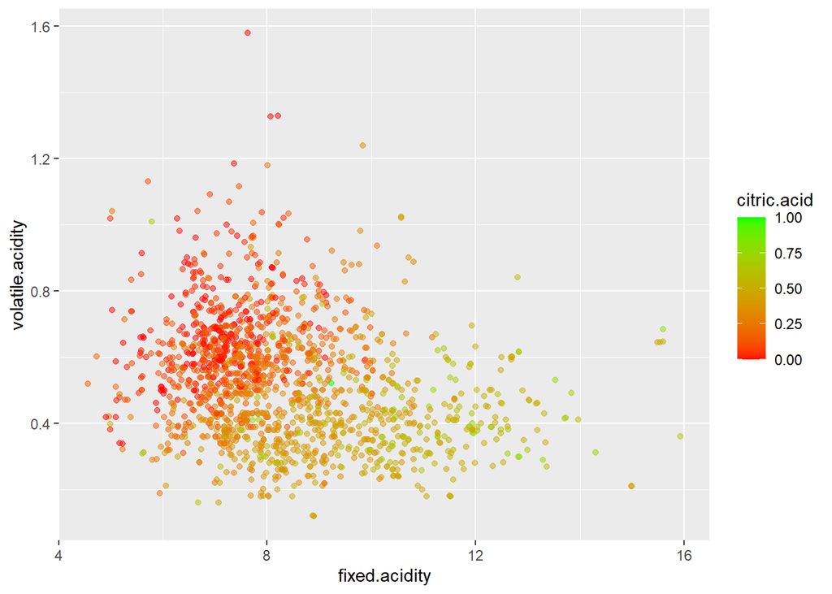

This graph shows that our while our citric acid decreases with volatile acidity it increases with fixed acidity. I don’t know why I didn’t think to look at that before, it appears that it is just an acid that does not evaporate readily as is necessary to be included in our volatile acidity. For fun let’s check out the bivariate graph of that relationship

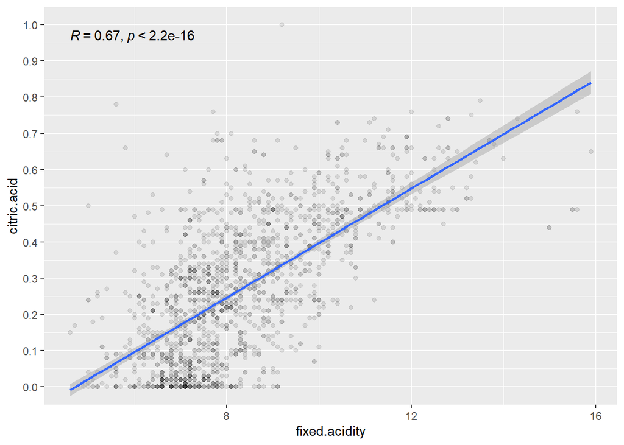

Indeed there is a strong correlation between citric acid and fixed acidity

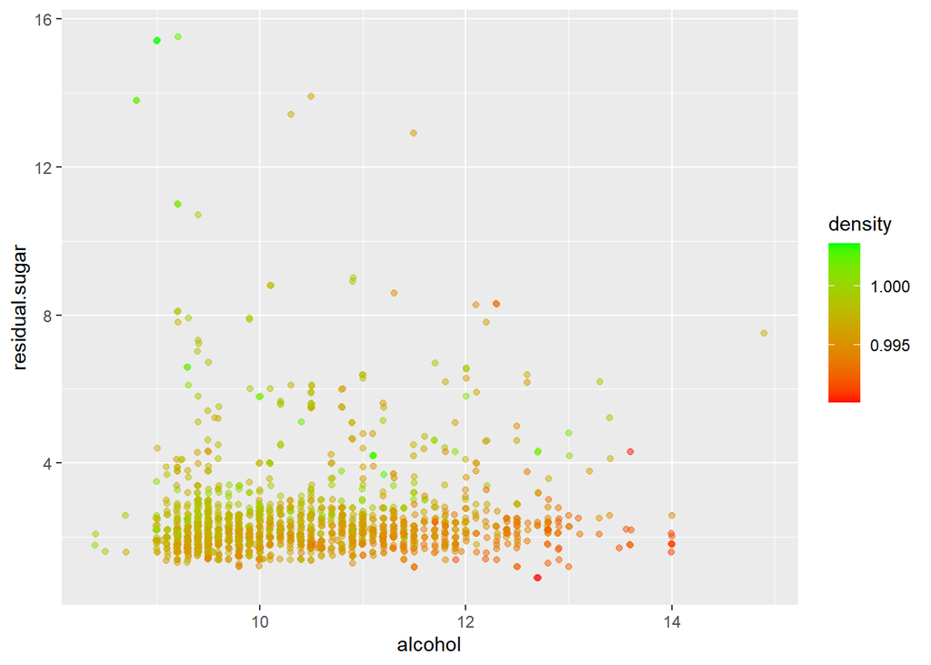

Here we show again that the lower the alcohol and the higher the residual sugar the higher the density, and the higher the alcohol and the lower the residual sugar the lower the density of our wines.

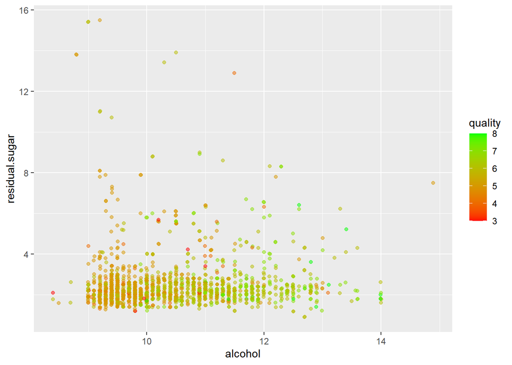

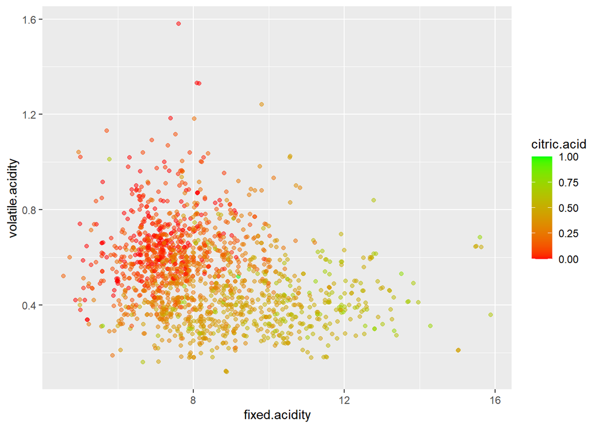

# Multivariate Analysis

investigation. Were there features that strengthened each other in terms of  
looking at your feature(s) of interest?

Mostly these were just a combination of bivariate conclusions less the fixed acidity vs citric acid.

### Were there any interesting or surprising interactions between features?

I was surprised to find that in observing the relationships between all of our acids, the fixed acidity was so closely related to the citric acid content.

# Final Plots and Summary

### Plot One: Residual Sugar

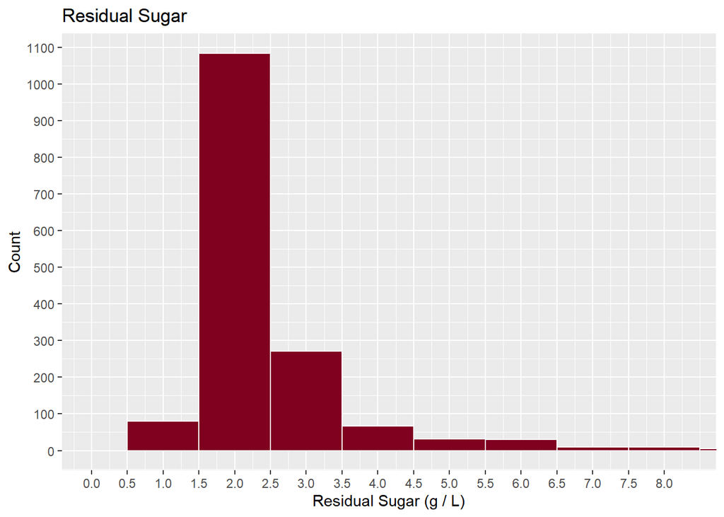

### Plot Two: Alcohol to Residual Sugar

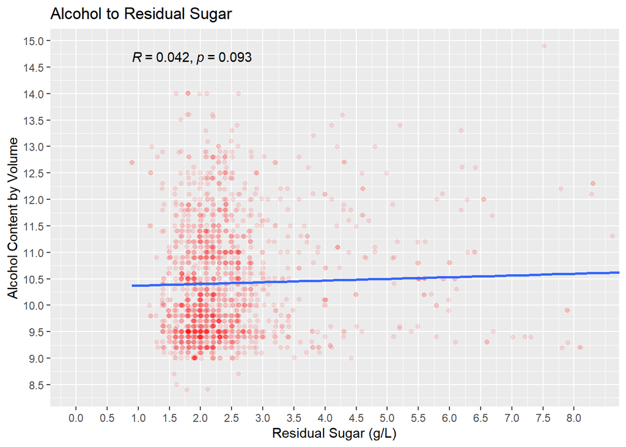

### Descriptionof Alcohol to Residual Sugar

In this graph we see the relationship between residual sugar in g/L and alcohol content by volume. We see by the R coefficient that there is a very weak correlation between the two when we should expect a strong correlation. This is likely due to our limited values of sugar where too many wines fall in a very tight limit on our sugar scale.

### Plot Three: Alcohol and Residual Sugar with Density

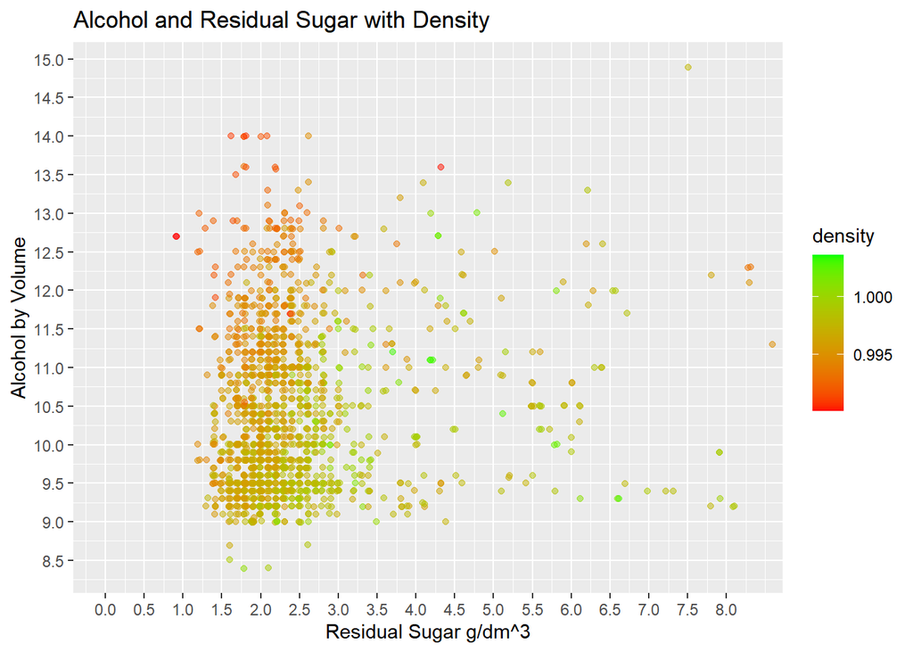

# Reflection

I believe this dataset to be incomplete or not representative of a good variety of wine due to the odd sugar content. Mostly I struggled with this concept as I initially felt I had done something wrong when I discovered this in our data. I was glad to find the explanation in the sugar content being so low. I was also pleased with the relationship between the preservatives and the alcohol where it seemed the relationship between alcohol and the various preservatives was vaguely negative which is what I expected.

It would be interesting to see finer relationships between quality and ratios of different substances, like the acid to sugar ratio and quality if the sugar was easier to work with and the same with chloride to sugar and acid.

It was interesting to see that sulphates were received more positively than most other aspects and that it is possible to taste the total sulfur dioxide and that it’s flavor made a noticeable impact on quality.